# Clustering

## K-means y DBSCAN + PCA

En este Anexo analizaremos la conveniencia de aplicar Análisis de Componentes Principales (PCA) previo al entrenamiento del modelo.

```python
import numpy as np
import matplotlib.pyplot as plt
import seaborn as sns
import pandas as pd
import plotly.express as px
from sklearn.cluster import KMeans
from sklearn.cluster import DBSCAN
from sklearn.cluster import AgglomerativeClustering
from scipy.cluster import hierarchy
from sklearn import preprocessing
from sklearn.preprocessing import StandardScaler
from sklearn.decomposition import PCA
import plotly.graph_objects as go
from plotly.subplots import make_subplots
from plotly.offline import init_notebook_mode
init_notebook_mode(connected=True)
import plotly.express as px
from utils import (quantile_target_distribution_plot_relative,
                   quantile_target_distribution_relative)
import warnings
warnings.filterwarnings('ignore')
```

```python
df = pd.read_csv('Mall_Customers.csv')
df.head()
```

|  | CustomerID | Gender | Age | Annual Income (k$) | Spending Score (1-100) |
| --- | --- | --- | --- | --- | --- |
| 0 | 1 | Male | 19 | 15 | 39 |
| 1 | 2 | Male | 21 | 15 | 81 |
| 2 | 3 | Female | 20 | 16 | 6 |
| 3 | 4 | Female | 23 | 16 | 77 |
| 4 | 5 | Female | 31 | 17 | 40 |

```python
fig = px.scatter(df, x="Annual Income (k$)", y="Spending Score (1-100)", color="Gender",
                 size='Age', hover_data=['Gender'])
fig.show()
```

[interactive chart not shown]

# KMEANS

Inicializamos KMEANS utilizando únicamente las variables numéricas de interés.

```python
features = ['Annual Income (k$)', 'Spending Score (1-100)']
X=df.loc[:, features].values
X.shape
```

```
(200, 2)
```

```python
kmeans_kwargs = {
    "init": "random",
    "n_init": 10,
    "max_iter": 300,
    "random_state": 0,
}
kmeans = KMeans(n_clusters=5, **kmeans_kwargs)
kmeans.fit(X)
kmeans.labels_.shape
kmeans_labels=kmeans.labels_
```

```python
X_kmeans=np.vstack(X)
etiquetas_kmeans=np.vstack(kmeans.labels_)
np_kmeans = np.append(X_kmeans, etiquetas_kmeans, axis = 1)
df_kmeans= pd.DataFrame(np_kmeans,
             columns=['Annual Income (k$)', 'Spending Score (1-100)', "kmeans_labels"])
df_kmeans['kmeans_labels'] = df_kmeans['kmeans_labels'].astype(str)
df_kmeans
```

|  | Annual Income (k$) | Spending Score (1-100) | kmeans_labels |
| --- | --- | --- | --- |
| 0 | 15 | 39 | 0 |
| 1 | 15 | 81 | 2 |
| 2 | 16 | 6 | 0 |
| 3 | 16 | 77 | 2 |
| 4 | 17 | 40 | 0 |
| ... | ... | ... | ... |
| 195 | 120 | 79 | 4 |
| 196 | 126 | 28 | 1 |
| 197 | 126 | 74 | 4 |
| 198 | 137 | 18 | 1 |
| 199 | 137 | 83 | 4 |

200 rows × 3 columns

# PRINCIPAL COMPONENTS ANALYSIS

En este apartado evaluamos la descomposición de las variables en hasta 2 componentes. Dado que partimos de 2 variables, evaluamos la reducción a 1 sola componente.

```python
#Realizamos el escalado previo de las variables originales utilizando StandardScaler.
features = ['Annual Income (k$)', 'Spending Score (1-100)']
x =df.loc[:, features].values
x = StandardScaler().fit_transform(x)
```

```python
pca = PCA(n_components=2)
principalComponents = pca.fit_transform(x)
principalDf = pd.DataFrame(data = principalComponents
             , columns = ['principal component 1', "principal component 2"])
```

La componente 1 explica el 50.5% de la variabilidad del modelo. Al usar 2 componentes, PC2 completará el 100%.

```python
np.cumsum(pca.explained_variance_ratio_)
```

```
array([0.50495142, 1.        ])
```

```python
principalComponents.shape
```

```
(200, 2)
```

```python
kmeans_ = KMeans(n_clusters=5, random_state=0)
kmeans_.fit(principalComponents)
```

```
KMeans(n_clusters=5, random_state=0)
```

```python
kmeans.labels_PCA = kmeans_.labels_
print(kmeans.labels_PCA.shape)
```

```
(200,)
```

```python
np.unique(kmeans.labels_PCA)
```

```
array([0, 1, 2, 3, 4])
```

```python
centros_ = kmeans_.cluster_centers_
print(centros_)
```

```
[[-0.16223578  1.65423536]
 [-0.16077398 -0.1233593 ]
 [ 1.5776159  -0.17530571]
 [-0.13955985 -1.74070117]
 [-1.72851125 -0.12059942]]
```

A continuación se muestra la distribución de las variables partiendo de los componentes principales, con sus respectivos centroides.

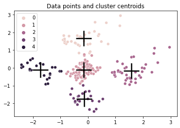

```python
sns.scatterplot(principalComponents[:, 0], principalComponents[:, -1], hue = kmeans.labels_PCA)
sns.scatterplot(centros_[:, 0], centros_[:, 1],color='black', marker="+", s=1000)
plt.title('Data points and cluster centroids')
plt.show()
```

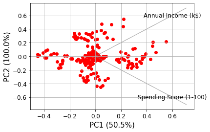

```python
import matplotlib.pyplot as plt
import numpy as np
plt.rcParams.update({'font.size': 12})
labels = features

def myplot(score,coeff,labels= labels):
    xs = score[:,0]
    ys = score[:,1]
    n = coeff.shape[0]
    scalex = 1.0/(xs.max() - xs.min())
    scaley = 1.0/(ys.max() - ys.min())
    plt.scatter(xs* scalex,ys * scaley, color = "red", s=35)
    for i in range(n):
        plt.arrow(0, 0, coeff[i,0], coeff[i,1],color = 'gray',alpha = 0.5)
        plt.text(coeff[i,0]* 0.85, coeff[i,1] * 0.85, labels[i], color = 'black', ha = 'center', va = 'center')
    plt.xlabel("PC1 (50.5%)", fontsize = 15)
    plt.ylabel("PC2 (100.0%)", fontsize = 15)
    plt.grid()

myplot(principalComponents[:,0:2],np.transpose(pca.components_[0:2, :]),labels)
plt.show()
```

Como vemos las variables originales Annual Income (k$) y Spending Score (1-100) son casi ortogonales. Esperamos que los clusters obtenidos aplicando PCA sean similares a los originales (sin PCA).

```python
X_kmeans_PCA=np.vstack(principalComponents)
etiquetas_kmeans_PCA=np.vstack(kmeans.labels_PCA)
np_kmeans_PCA = np.append(X_kmeans_PCA, etiquetas_kmeans_PCA, axis = 1)
```

```python
df_kmeans_PCA= pd.DataFrame(np_kmeans_PCA,
             columns=['kmeans_PC1', 'kmeans_PC2', "kmeans_labels_PCA"])
df_kmeans_PCA['kmeans_labels_PCA'] = df_kmeans_PCA['kmeans_labels_PCA'].astype(str)
```

```python
df_kmeans_PCA.head()
```

|  | kmeans_PC1 | kmeans_PC2 | kmeans_labels_PCA |
| --- | --- | --- | --- |
| 0 | -1.537109 | -0.922207 | 4.0 |
| 1 | -0.384168 | -2.075149 | 3.0 |
| 2 | -2.416002 | 0.010665 | 4.0 |
| 3 | -0.466982 | -1.938355 | 3.0 |
| 4 | -1.455678 | -0.895678 | 4.0 |

```python
fig = px.histogram(df_kmeans_PCA, x="kmeans_PC1", y="kmeans_PC2", color="kmeans_labels_PCA")
fig.show()
```

[interactive chart not shown]

A modo comparativo incluimos en un dataframe final la información de kmeans_labels y kmeans_labels_PCA

```python
df_final_kmeans=pd.concat([df["Annual Income (k$)"], df["Spending Score (1-100)"], df_kmeans["kmeans_labels"], df_kmeans_PCA["kmeans_labels_PCA"]], axis=1)
df_final_kmeans
```

|  | Annual Income (k$) | Spending Score (1-100) | kmeans_labels | kmeans_labels_PCA |
| --- | --- | --- | --- | --- |
| 0 | 15 | 39 | 0 | 4.0 |
| 1 | 15 | 81 | 2 | 3.0 |
| 2 | 16 | 6 | 0 | 4.0 |
| 3 | 16 | 77 | 2 | 3.0 |
| 4 | 17 | 40 | 0 | 4.0 |
| ... | ... | ... | ... | ... |
| 195 | 120 | 79 | 4 | 2.0 |
| 196 | 126 | 28 | 1 | 0.0 |
| 197 | 126 | 74 | 4 | 2.0 |
| 198 | 137 | 18 | 1 | 0.0 |
| 199 | 137 | 83 | 4 | 2.0 |

200 rows × 4 columns

A continuación comparamos gráficamente la asignación de clusters con y sin PCA.

```python
df_final_kmeans["kmeans_labels"]=df_final_kmeans["kmeans_labels"].astype(float)
df_final_kmeans["kmeans_labels_PCA"]=df_final_kmeans["kmeans_labels_PCA"].astype(float)
IQ_kmeans_PCA=quantile_target_distribution_relative(df_final_kmeans, "Annual Income (k$)", nq=5, target='kmeans_labels_PCA')
IQ_kmeans=quantile_target_distribution_relative(df_final_kmeans, "Annual Income (k$)", nq=5, target='kmeans_labels')
```

```python
fig = px.bar(IQ_kmeans,
            x ='INTERVAL',
            y='PROPORTION',
            color='kmeans_labels',
            barmode='relative',
            height=1000)
fig.show()
fig = px.bar(IQ_kmeans_PCA,
             x ='INTERVAL',
             y='PROPORTION',
             color='kmeans_labels_PCA',
             barmode='relative',
             height=1000)
fig.show()
```

[interactive chart not shown]

Observamos que los clusters cambian de nombre (número) pero los segmentos de clientes tienen las mismas conformaciones.

# INICIALIZAMOS DBSCAN

```python
db_ = DBSCAN(eps=9, min_samples=3)
db_.fit(X)
# Consultamos las etiquetas
DBSCAN_labels = db_.labels_

# Number of clusters in labels, ignoring noise if present.
n_clusters_ = len(set(DBSCAN_labels)) - (1 if -1 in DBSCAN_labels else 0)
n_noise_ = list(DBSCAN_labels).count(-1)
```

```python
X_DBSCAN=np.vstack(X)
etiquetas_DB=np.vstack(DBSCAN_labels)
np_DBSCAN = np.append(X_DBSCAN, etiquetas_DB, axis = 1)
df_DBSCAN= pd.DataFrame(np_DBSCAN,
             columns=['Annual Income', 'Spending Score', "DBSCAN_labels"])
df_DBSCAN.head()
```

|  | Annual Income | Spending Score | DBSCAN_labels |
| --- | --- | --- | --- |
| 0 | 15 | 39 | 0 |
| 1 | 15 | 81 | 1 |
| 2 | 16 | 6 | 2 |
| 3 | 16 | 77 | 1 |
| 4 | 17 | 40 | 0 |

# DBSCAN CON PCA

```python
db_ = DBSCAN(eps=0.35, min_samples=4)
```

```python
X1=principalComponents
```

```python
db_.fit(X1)
```

```
DBSCAN(eps=0.35, min_samples=4)
```

```python
DBSCAN_labels_PCA = db_.labels_
n_clusters_ = len(set(DBSCAN_labels_PCA)) - (1 if -1 in DBSCAN_labels_PCA else 0)
n_noise_ = list(DBSCAN_labels_PCA).count(-1)
```

```python
print('Estimated number of clusters: %d' % n_clusters_)
print('Estimated number of noise points: %d' % n_noise_)
```

```
Estimated number of clusters: 7
Estimated number of noise points: 16
```

```python
def plot_DBSCAN(X1,DBSCAN_labels_PCA,db_,n_clusters_):
    core_samples_mask_ = np.zeros_like(db_.labels_, dtype=bool)
    core_samples_mask_[db_.core_sample_indices_] = True
    unique_labels = set(DBSCAN_labels_PCA)
    colors = [plt.cm.Spectral(each)
              for each in np.linspace(0, 1, len(unique_labels))]
    for k, col in zip(unique_labels, colors):
        if k == -1:
            col = [0, 0, 0, 1]

        class_member_mask = (DBSCAN_labels_PCA == k)

        xy = X1[class_member_mask & core_samples_mask_]
        plt.plot(xy[:, 0], xy[:, 1], 'o', markerfacecolor=tuple(col),
                 markeredgecolor='k', markersize=14)

        xy = X1[class_member_mask & ~core_samples_mask_]
        plt.plot(xy[:, 0], xy[:, 1], 'o', markerfacecolor=tuple(col),
                 markeredgecolor='k', markersize=6)
    plt.title('Estimated number of clusters: %d' % n_clusters_)
    plt.show()
    return
```

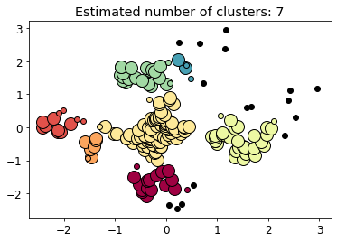

```python
plot_DBSCAN(X1,DBSCAN_labels_PCA,db_,n_clusters_)
```

```python
X_DBSCAN_PCA=np.vstack(principalComponents)
etiquetas_dbscan_PCA=np.vstack(DBSCAN_labels_PCA)
np_DBSCAN_PCA = np.append(X_DBSCAN_PCA, etiquetas_dbscan_PCA, axis = 1)
np_DBSCAN_PCA.shape
```

```
(200, 3)
```

```python
df_DBSCAN_PCA= pd.DataFrame(np_DBSCAN_PCA,
             columns=['DBSCAN_PC1', 'DBSCAN_PC2', "DBSCAN_labels_PCA"])
df_DBSCAN_PCA["DBSCAN_labels_PCA"] = df_DBSCAN_PCA['DBSCAN_labels_PCA'].astype(str)
df_DBSCAN_PCA.describe()
```

|  | DBSCAN_PC1 | DBSCAN_PC2 |
| --- | --- | --- |
| count | 2.000000e+02 | 2.000000e+02 |
| mean | 2.131628e-16 | 7.105427e-17 |
| std | 1.007461e+00 | 9.975332e-01 |
| min | -2.417385e+00 | -2.461307e+00 |
| 25% | -4.323694e-01 | -4.499386e-01 |
| 50% | -1.251055e-01 | -1.185058e-01 |
| 75% | 3.607120e-01 | 3.008815e-01 |
| max | 2.963498e+00 | 2.947027e+00 |

```python
fig = px.histogram(df_DBSCAN_PCA, x="DBSCAN_PC1", y="DBSCAN_PC2", color="DBSCAN_labels_PCA")
fig.show()
```

[interactive chart not shown]

```python
df_final_DBSCAN=pd.concat([df["Annual Income (k$)"], df["Spending Score (1-100)"], df_DBSCAN["DBSCAN_labels"], df_DBSCAN_PCA["DBSCAN_labels_PCA"]], axis=1)
df_final_DBSCAN
```

|  | Annual Income (k$) | Spending Score (1-100) | DBSCAN_labels | DBSCAN_labels_PCA |
| --- | --- | --- | --- | --- |
| 0 | 15 | 39 | 0 | 2.0 |
| 1 | 15 | 81 | 1 | 0.0 |
| 2 | 16 | 6 | 2 | 1.0 |
| 3 | 16 | 77 | 1 | 0.0 |
| 4 | 17 | 40 | 0 | 2.0 |
| ... | ... | ... | ... | ... |
| 195 | 120 | 79 | -1 | -1.0 |
| 196 | 126 | 28 | -1 | -1.0 |
| 197 | 126 | 74 | -1 | -1.0 |
| 198 | 137 | 18 | -1 | -1.0 |
| 199 | 137 | 83 | -1 | -1.0 |

200 rows × 4 columns

A continuación se presenta la descripción de los clusters para DBSCAN.

```python
df_DBSCAN_cluster0 = df_DBSCAN[df_DBSCAN["DBSCAN_labels"]==0]
df_DBSCAN_cluster1 = df_DBSCAN[df_DBSCAN["DBSCAN_labels"]==1]
df_DBSCAN_cluster2 = df_DBSCAN[df_DBSCAN["DBSCAN_labels"]==2]
df_DBSCAN_cluster3 = df_DBSCAN[df_DBSCAN["DBSCAN_labels"]==3]
df_DBSCAN_cluster4 = df_DBSCAN[df_DBSCAN["DBSCAN_labels"]==4]
df_DBSCAN_cluster5 = df_DBSCAN[df_DBSCAN["DBSCAN_labels"]==5]
df_DBSCAN_cluster6 = df_DBSCAN[df_DBSCAN["DBSCAN_labels"]==6]
df_DBSCAN_cluster7 = df_DBSCAN[df_DBSCAN["DBSCAN_labels"]==-1]

print("Cluster 0: ")
print(df_DBSCAN_cluster0.describe())
print('------------------------------------')
print("Cluster 1: ")
print(df_DBSCAN_cluster1.describe())
print('------------------------------------')
print("Cluster 2: ")
print(df_DBSCAN_cluster2.describe())
print('------------------------------------')
print("Cluster 3: ")
print(df_DBSCAN_cluster3.describe())
print('------------------------------------')
print("Cluster 4: ")
print(df_DBSCAN_cluster4.describe())
print('------------------------------------')
print("Cluster 5: ")
print(df_DBSCAN_cluster5.describe())
print('------------------------------------')
print("Cluster 6: ")
print(df_DBSCAN_cluster6.describe())
print('------------------------------------')
print("Cluster Outliers: ")
print(df_DBSCAN_cluster7.describe())
print('------------------------------------')
```

```
Cluster 0:
       Annual Income  Spending Score  DBSCAN_labels
count       7.000000        7.000000            7.0
mean       22.428571       34.428571            0.0
std         5.223573        4.076647            0.0
min        15.000000       29.000000            0.0
25%        19.000000       31.500000            0.0
50%        23.000000       35.000000            0.0
75%        26.000000       37.000000            0.0
max        29.000000       40.000000            0.0
------------------------------------
Cluster 1:
       Annual Income  Spending Score  DBSCAN_labels
count      18.000000       18.000000           18.0
mean       25.944444       77.222222            1.0
std         7.328207        7.974633            0.0
min        15.000000       61.000000            1.0
25%        20.000000       73.000000            1.0
50%        26.500000       76.500000            1.0
75%        32.250000       81.000000            1.0
max        38.000000       92.000000            1.0
------------------------------------
Cluster 2:
       Annual Income  Spending Score  DBSCAN_labels
count      12.000000       12.000000           12.0
mean       24.583333        9.583333            2.0
std         6.694072        5.282188            0.0
min        16.000000        3.000000            2.0
25%        19.000000        4.750000            2.0
50%        22.500000        9.500000            2.0
75%        30.750000       14.000000            2.0
max        34.000000       17.000000            2.0
------------------------------------
Cluster 3:
       Annual Income  Spending Score  DBSCAN_labels
count       3.000000        3.000000            3.0
mean       20.000000       97.000000            3.0
std         2.645751        2.645751            0.0
min        18.000000       94.000000            3.0
25%        18.500000       96.000000            3.0
```

[output cut: 33 more lines]

```
50%        83.000000       14.500000            6.0
75%        89.250000       20.500000            6.0
max       103.000000       39.000000            6.0
------------------------------------
Cluster Outliers:
       Annual Income  Spending Score  DBSCAN_labels
count      11.000000       11.000000           11.0
mean      117.727273       57.363636           -1.0
std        13.349838       33.034142            0.0
min        99.000000        8.000000           -1.0
25%       108.000000       23.000000           -1.0
50%       120.000000       69.000000           -1.0
75%       126.000000       81.000000           -1.0
max       137.000000       97.000000           -1.0
------------------------------------
```

```python
df_final_DBSCAN["DBSCAN_labels_PCA"]=df_final_DBSCAN["DBSCAN_labels_PCA"].astype(float)
df_cluster0_PCA = df_final_DBSCAN[df_final_DBSCAN["DBSCAN_labels_PCA"]==0.0]
df_cluster1_PCA = df_final_DBSCAN[df_final_DBSCAN["DBSCAN_labels_PCA"]==1.0]
df_cluster2_PCA = df_final_DBSCAN[df_final_DBSCAN["DBSCAN_labels_PCA"]==2.0]
df_cluster3_PCA = df_final_DBSCAN[df_final_DBSCAN["DBSCAN_labels_PCA"]==3.0]
df_cluster4_PCA = df_final_DBSCAN[df_final_DBSCAN["DBSCAN_labels_PCA"]==4.0]
df_cluster5_PCA = df_final_DBSCAN[df_final_DBSCAN["DBSCAN_labels_PCA"]==5.0]
df_cluster6_PCA = df_final_DBSCAN[df_final_DBSCAN["DBSCAN_labels_PCA"]==6.0]
df_cluster_out_PCA = df_final_DBSCAN[df_final_DBSCAN["DBSCAN_labels_PCA"]==-1.0]

print("Cluster 0: ")
print(df_cluster0_PCA.describe())
print('------------------------------------')
print("Cluster 1: ")
print(df_cluster1_PCA.describe())
print('------------------------------------')
print("Cluster 2: ")
print(df_cluster2_PCA.describe())
print('------------------------------------')
print("Cluster 3: ")
print(df_cluster3_PCA.describe())
print('------------------------------------')
print("Cluster 4: ")
print(df_cluster4_PCA.describe())
print('------------------------------------')
print("Cluster 5: ")
print(df_cluster5_PCA.describe())
print('------------------------------------')
print("Cluster 6: ")
print(df_cluster6_PCA.describe())
print('------------------------------------')
print("Cluster -1: ")
print(df_cluster_out_PCA.describe())
print('------------------------------------')
```

```
Cluster 0:
       Annual Income (k$)  Spending Score (1-100)  DBSCAN_labels  \
count           17.000000               17.000000           17.0
mean            25.235294               76.352941            1.0
std              6.887756                7.288185            0.0
min             15.000000               61.000000            1.0
25%             20.000000               73.000000            1.0
50%             25.000000               76.000000            1.0
75%             30.000000               81.000000            1.0
max             37.000000               92.000000            1.0

       DBSCAN_labels_PCA
count               17.0
mean                 0.0
std                  0.0
min                  0.0
25%                  0.0
50%                  0.0
75%                  0.0
max                  0.0
------------------------------------
Cluster 1:
       Annual Income (k$)  Spending Score (1-100)  DBSCAN_labels  \
count           12.000000               12.000000           12.0
mean            24.583333                9.583333            2.0
std              6.694072                5.282188            0.0
min             16.000000                3.000000            2.0
25%             19.000000                4.750000            2.0
50%             22.500000                9.500000            2.0
75%             30.750000               14.000000            2.0
max             34.000000               17.000000            2.0

       DBSCAN_labels_PCA
count               12.0
mean                 1.0
std                  0.0
min                  1.0
25%                  1.0
50%                  1.0
75%                  1.0
```

[output cut: 113 more lines]

```
25%             83.750000               36.250000      -1.000000
50%            108.000000               76.500000      -1.000000
75%            121.500000               92.500000       1.500000
max            137.000000               99.000000       6.000000

       DBSCAN_labels_PCA
count               16.0
mean                -1.0
std                  0.0
min                 -1.0
25%                 -1.0
50%                 -1.0
75%                 -1.0
max                 -1.0
------------------------------------
```

Evaluamos las distribuciones de los segmentos de clientes para comparar los resultados con y sin PCA.

```python
IQ_DBSCAN_PCA=quantile_target_distribution_relative(df_final_DBSCAN, "Annual Income (k$)", nq=5, target='DBSCAN_labels_PCA')
IQ_DBSCAN=quantile_target_distribution_relative(df_final_DBSCAN, "Annual Income (k$)", nq=5, target='DBSCAN_labels')
```

```python
fig = px.bar(IQ_DBSCAN,
             x ='INTERVAL',
             y='PROPORTION',
             color='DBSCAN_labels',
             barmode='relative',
             height=1000)
fig.show()
fig = px.bar(IQ_DBSCAN_PCA,
             x ='INTERVAL',
             y='PROPORTION',
             color='DBSCAN_labels_PCA',
             barmode='relative',
             height=1000)
fig.show()
```

[interactive chart not shown]

En este caso observamos diferencias en las configuraciones de clusters con y sin PCA. Para DBSCAN se obtuvieron 11 outliers y para DBSCAN_PCA 16. Además, los outliers se agruparon de diferente manera para la variable Annual Income.

# INICIALIZAMOS AGGLOMERATIVE

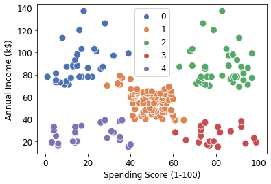

```python
aggloclust = AgglomerativeClustering(distance_threshold=200, n_clusters=None).fit(X)
sns.scatterplot(x=df['Spending Score (1-100)'],
                y=df['Annual Income (k$)'],
                s=100,
                hue = aggloclust.labels_,
                palette="deep",
                legend=True)
plt.show()
```

```python
Agg_labels=aggloclust.labels_
etiquetas_agg=np.vstack(Agg_labels)
X_agg=np.vstack(X)
np_Agg = np.append(X_agg, etiquetas_agg, axis = 1)
df_Agg= pd.DataFrame(np_Agg,
             columns=['Annual Income', 'Spending Score', "Agg_labels"])
df_Agg
```

|  | Annual Income | Spending Score | Agg_labels |
| --- | --- | --- | --- |
| 0 | 15 | 39 | 4 |
| 1 | 15 | 81 | 3 |
| 2 | 16 | 6 | 4 |
| 3 | 16 | 77 | 3 |
| 4 | 17 | 40 | 4 |
| ... | ... | ... | ... |
| 195 | 120 | 79 | 2 |
| 196 | 126 | 28 | 0 |
| 197 | 126 | 74 | 2 |
| 198 | 137 | 18 | 0 |
| 199 | 137 | 83 | 2 |

200 rows × 3 columns

## Agglomerative + PCA

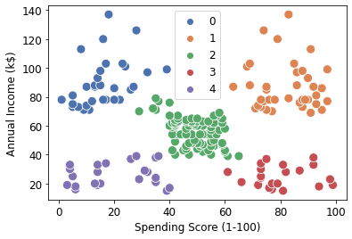

```python
aggloclust = AgglomerativeClustering(distance_threshold=5, n_clusters=None).fit(X1)
sns.scatterplot(x=df['Spending Score (1-100)'],
                y=df['Annual Income (k$)'],
                s=100,
                hue = aggloclust.labels_,
                palette="deep",
                legend=True)
plt.show()
```

```python
Agg_labels_PCA=aggloclust.labels_
etiquetas_agg_PCA=np.vstack(Agg_labels_PCA)
X_agg_PCA=np.vstack(X1)
```

```python
np_Agg_PCA = np.append(X_agg_PCA, etiquetas_agg_PCA, axis = 1)
np_Agg_PCA.shape
```

```
(200, 3)
```

```python
df_Agg_PCA= pd.DataFrame(np_Agg_PCA,
             columns=['Agg_PC1', 'Agg_PC2', "Agg_labels_PCA"])
```

```python
df_Agg_PCA.shape
```

```
(200, 3)
```

```python
df_final_Agg=pd.concat([df["Annual Income (k$)"], df["Spending Score (1-100)"], df_Agg["Agg_labels"], df_Agg_PCA["Agg_labels_PCA"]], axis=1)
df_final_Agg
```

|  | Annual Income (k$) | Spending Score (1-100) | Agg_labels | Agg_labels_PCA |
| --- | --- | --- | --- | --- |
| 0 | 15 | 39 | 4 | 4.0 |
| 1 | 15 | 81 | 3 | 3.0 |
| 2 | 16 | 6 | 4 | 4.0 |
| 3 | 16 | 77 | 3 | 3.0 |
| 4 | 17 | 40 | 4 | 4.0 |
| ... | ... | ... | ... | ... |
| 195 | 120 | 79 | 2 | 1.0 |
| 196 | 126 | 28 | 0 | 0.0 |
| 197 | 126 | 74 | 2 | 1.0 |
| 198 | 137 | 18 | 0 | 0.0 |
| 199 | 137 | 83 | 2 | 1.0 |

200 rows × 4 columns

Observamos algunas diferencias en la segmentación tras la aplicación de PCA para Agglomerative Cluster.

```python
df_final_Agg["Agg_labels"].astype(float)==df_final_Agg["Agg_labels_PCA"].astype(float)
```

```
0       True
1       True
2       True
3       True
4       True
       ...
195    False
196     True
197    False
198     True
199    False
Length: 200, dtype: bool
```

Evaluamos las distribuciones de los segmentos de clientes para comparar los resultados con y sin PCA. Comprobamos que fueron asignados diferentes números de clusters para nombrar a los segmentos pero las configuraciones son las mismas.

```python
IQ_Agg_PCA=quantile_target_distribution_relative(df_final_Agg, "Annual Income (k$)", nq=5, target='Agg_labels_PCA')
IQ_Agg=quantile_target_distribution_relative(df_final_Agg, "Annual Income (k$)", nq=5, target='Agg_labels')
```

```python
fig = px.bar(IQ_Agg,
             x ='INTERVAL',
             y='PROPORTION',
             color='Agg_labels',
             barmode='relative',
             height=1000)
fig.show()
fig = px.bar(IQ_Agg_PCA,
             x ='INTERVAL',
             y='PROPORTION',
             color='Agg_labels_PCA',
             barmode='relative',
             height=1000)
fig.show()
```

[interactive chart not shown]

# ANÁLISIS FINAL DE RESULTADOS

```python
FINAL=pd.concat([df_kmeans["kmeans_labels"], df_kmeans_PCA["kmeans_labels_PCA"], df_DBSCAN["DBSCAN_labels"], df_DBSCAN_PCA["DBSCAN_labels_PCA"], df_Agg["Agg_labels"], df_Agg_PCA["Agg_labels_PCA"]], axis=1)
FINAL
```

|  | kmeans_labels | kmeans_labels_PCA | DBSCAN_labels | DBSCAN_labels_PCA | Agg_labels | Agg_labels_PCA |
| --- | --- | --- | --- | --- | --- | --- |
| 0 | 0 | 4.0 | 0 | 2.0 | 4 | 4.0 |
| 1 | 2 | 3.0 | 1 | 0.0 | 3 | 3.0 |
| 2 | 0 | 4.0 | 2 | 1.0 | 4 | 4.0 |
| 3 | 2 | 3.0 | 1 | 0.0 | 3 | 3.0 |
| 4 | 0 | 4.0 | 0 | 2.0 | 4 | 4.0 |
| ... | ... | ... | ... | ... | ... | ... |
| 195 | 4 | 2.0 | -1 | -1.0 | 2 | 1.0 |
| 196 | 1 | 0.0 | -1 | -1.0 | 0 | 0.0 |
| 197 | 4 | 2.0 | -1 | -1.0 | 2 | 1.0 |
| 198 | 1 | 0.0 | -1 | -1.0 | 0 | 0.0 |
| 199 | 4 | 2.0 | -1 | -1.0 | 2 | 1.0 |

200 rows × 6 columns

```python
FINAL["kmeans_labels"]=FINAL["kmeans_labels"].astype(float)
FINAL["kmeans_labels_PCA"]=FINAL["kmeans_labels_PCA"].astype(float)
FINAL["DBSCAN_labels"]=FINAL["DBSCAN_labels"].astype(float)
FINAL["DBSCAN_labels_PCA"]=FINAL["DBSCAN_labels_PCA"].astype(float)
FINAL["Agg_labels"]=FINAL["Agg_labels"].astype(float)
FINAL.info()
```

```
<class 'pandas.core.frame.DataFrame'>
RangeIndex: 200 entries, 0 to 199
Data columns (total 6 columns):
 #   Column             Non-Null Count  Dtype
---  ------             --------------  -----
 0   kmeans_labels      200 non-null    float64
 1   kmeans_labels_PCA  200 non-null    float64
 2   DBSCAN_labels      200 non-null    float64
 3   DBSCAN_labels_PCA  200 non-null    float64
 4   Agg_labels         200 non-null    float64
 5   Agg_labels_PCA     200 non-null    float64
dtypes: float64(6)
memory usage: 9.5 KB
```

Debemos tener en cuenta para el mapeo que diferentes números de clúster podrían representar a los mismos segmentos utilizando métodos de clustering distintos.

```python
labels_mapper_kmeans = {0: 'Cautious spenders',
                 1: 'Middle-class',
                 2: 'Top customers',
                 3: 'Impetuous buyers',
                 4: 'Inactive customers',
                 5: "Others",
                 6: "Others"}
```

```python
labels_mapper_kmeans_PCA = {4: 'Cautious spenders',
                 0: 'Middle-class',
                 3: 'Top customers',
                 1: 'Impetuous buyers',
                 2: 'Inactive customers',
                 5: "Others",
                 6: "Others"}
```

```python
labels_mapper_DBSCAN = {0: 'Low middle-class',
                 1: 'Impetuous buyers',
                 2: 'Inactive customers',
                 3: 'High Impetuous buyers',
                 4: 'Middle-class',
                 5: "Top customers",
                 6: "Cautious spenders",
                 -1: "Outliers"      }
```

```python
labels_mapper_DBSCAN_PCA = {0: 'Impetuous buyers',
                 1: 'Inactive customers',
                 2: 'Low middle-class',
                 3: 'Middle-class',
                 4: 'Top customers',
                 5: "Low Cautious spenders",
                 6: "High Cautious spenders",
                 -1: "Outliers"      }
```

```python
labels_mapper_Agg = {0: 'Cautious spenders',
                 1: 'Middle-class',
                 2: 'Top customers',
                 3: 'Impetuous buyers',
                 4: 'Inactive customers',
                 5: "Others",
                 6: "Others",
                 -1: "Outliers"}
```

```python
labels_mapper_Agg_PCA = {0: 'Cautious spenders',
                 2: 'Middle-class',
                 1: 'Top customers',
                 3: 'Impetuous buyers',
                 4: 'Inactive customers',
                 5: "Others",
                 6: "Others",
                 -1: "Outliers"}
```

```python
df_FINAL = FINAL.copy()
df_FINAL['kmeans_labels']= df_FINAL['kmeans_labels'].map(labels_mapper_kmeans)
df_FINAL["kmeans_labels_PCA"]= df_FINAL["kmeans_labels_PCA"].map(labels_mapper_kmeans_PCA)
df_FINAL["DBSCAN_labels"]= df_FINAL["DBSCAN_labels"].map(labels_mapper_DBSCAN)
df_FINAL["DBSCAN_labels_PCA"]= df_FINAL["DBSCAN_labels_PCA"].map(labels_mapper_DBSCAN_PCA)
df_FINAL["Agg_labels"]= df_FINAL["Agg_labels"].map(labels_mapper_Agg)
df_FINAL["Agg_labels_PCA"]= df_FINAL["Agg_labels_PCA"].map(labels_mapper_Agg_PCA)
Final_ = pd.concat([df_FINAL, df["Annual Income (k$)"], df["Spending Score (1-100)"]], axis=1)
```

```python
Final_
```

|  | kmeans_labels | kmeans_labels_PCA | DBSCAN_labels | DBSCAN_labels_PCA | Agg_labels | Agg_labels_PCA | Annual Income (k$) | Spending Score (1-100) |
| --- | --- | --- | --- | --- | --- | --- | --- | --- |
| 0 | Cautious spenders | Cautious spenders | Low middle-class | Low middle-class | Inactive customers | Inactive customers | 15 | 39 |
| 1 | Top customers | Top customers | Impetuous buyers | Impetuous buyers | Impetuous buyers | Impetuous buyers | 15 | 81 |
| 2 | Cautious spenders | Cautious spenders | Inactive customers | Inactive customers | Inactive customers | Inactive customers | 16 | 6 |
| 3 | Top customers | Top customers | Impetuous buyers | Impetuous buyers | Impetuous buyers | Impetuous buyers | 16 | 77 |
| 4 | Cautious spenders | Cautious spenders | Low middle-class | Low middle-class | Inactive customers | Inactive customers | 17 | 40 |
| ... | ... | ... | ... | ... | ... | ... | ... | ... |
| 195 | Inactive customers | Inactive customers | Outliers | Outliers | Top customers | Top customers | 120 | 79 |
| 196 | Middle-class | Middle-class | Outliers | Outliers | Cautious spenders | Cautious spenders | 126 | 28 |
| 197 | Inactive customers | Inactive customers | Outliers | Outliers | Top customers | Top customers | 126 | 74 |
| 198 | Middle-class | Middle-class | Outliers | Outliers | Cautious spenders | Cautious spenders | 137 | 18 |
| 199 | Inactive customers | Inactive customers | Outliers | Outliers | Top customers | Top customers | 137 | 83 |

200 rows × 8 columns

Notamos diferencias en la asignación de clusters tras PCA únicamente aplicando DBSCAN.

```python
(df_FINAL["DBSCAN_labels"]==df_FINAL["DBSCAN_labels_PCA"]).value_counts()
```

```
True     168
False     32
dtype: int64
```

```python
(df_FINAL["kmeans_labels"]==df_FINAL["kmeans_labels_PCA"]).value_counts()
```

```
True    200
dtype: int64
```

```python
(df_FINAL["Agg_labels"]==df_FINAL["Agg_labels_PCA"]).value_counts()
```

```
True    200
dtype: int64
```

Conclusiones:

No se justifica la reducción de variables aplicando PCA, dado que PC1 explica únicamente el 50.5% de la variabilidad.

Considerando 2 PCA's, la transformación de las variables mostró diferencias para la asignación de clústers en el método DBSCAN. Se identificaron 7 segmentos pero en el caso de DBSCAN_PCA el segmento: "Cautious spenders" se dividió en dos clústers que renombramos como: "Low Cautious spenders" (Annual Income (mean): 81k, Spending Score (mean): 13) y "High Cautious spenders" (Annual Income (mean): 101k, Spending Score (mean): 24). Asimismo, el método DBSCAN_PCA identificó 16 outliers, mientras que DBSCAN identificó 11.

No se observaron diferencias aplicando PCA para los métodos kmeans y Agglomerative Clustering.